# Project Markdown

### Loading and preprocessing the data

```r
if(!file.exists("getdata-projectfiles-UCI HAR Dataset.zip")) {
  Data <- tempfile()
    download.file("http://d396qusza40orc.cloudfront.net/repdata%2Fdata%2Factivity.zip",Data)
    unzip(Data)
    unlink(Data)}
activity <- read.csv("activity.csv")
```

### What is mean total number of steps taken per day

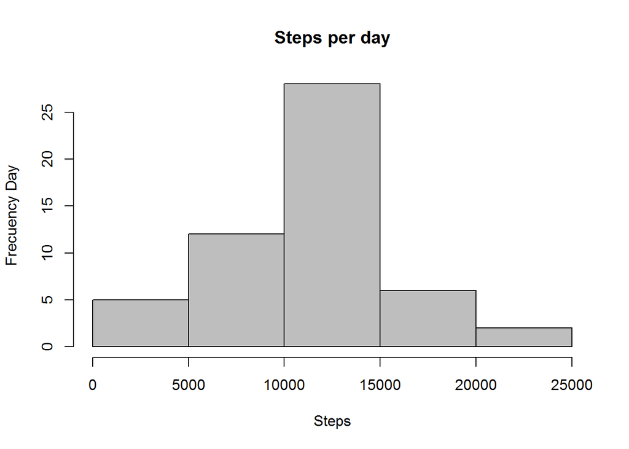

```r
stepsday<-aggregate(steps~date,activity, sum)

hist(stepsday$steps, main="Steps per day", xlab="Steps", ylab = "Frecuency Day", col="grey")
```

#### Mean steps by day

```r
mean_steps <- mean(stepsday$steps)
```

#### Median steps by day

```r
median_steps <- median(stepsday$steps)
```

##### The mean is

```
## [1] 10766.19
```

##### The median is

```
## [1] 10765
```

### What is the average daily activity pattern?

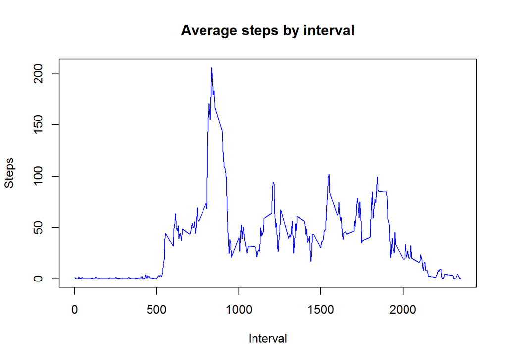

```r
steps_average<- aggregate(steps~interval, activity, mean)

plot(steps_average$interval,steps_average$steps, type ="l", col="blue", xlab = "Interval", ylab="Steps", main ="Average steps by interval")
```

#### Interval that contains the maximum number of steps On average across all the days in the dataset

```r
max_steps_average <- steps_average[which.max(steps_average$steps),1]
```

##### The 5-minute interval, on average across all the days in the data set, containing the maximum number of steps is

```
## [1] 835
```

### Imputing missing values

##### Create a new dataset that is equal to the original dataset but with the missing data filled in.

#### number of missing values in the data

```r
sum(!complete.cases(activity))
```

```
## [1] 2304
```

#### Devise a strategy for filling in all of the missing values in the dataset.

```r
activity_imputed <- transform(activity,steps = ifelse(is.na(activity$steps), steps_average$steps[match(activity$interval,steps_average$interval)],activity$steps))
```

```r
activity_imputed[as.character(activity_imputed$date) == "2012-10-01", 1] <- 0
```

##### histogram of the total number of steps taken each day and Calculate and report the mean and total number of steps taken per day

```r
stepsday2 <- aggregate(steps~date ,activity_imputed,sum)
```

##### Data vs imputed data through histrogram

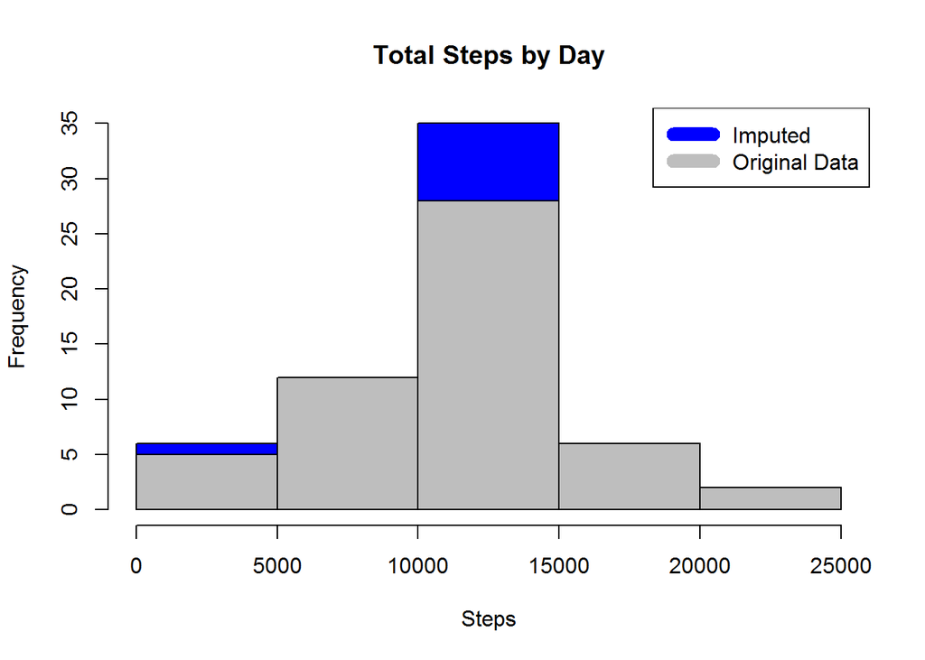

```r
stepsday_imputed <- aggregate(steps ~ date, activity_imputed, sum)
hist(stepsday_imputed$steps, main = "Total Steps by Day", col="blue", xlab="Steps")

#Histogram that show difference.
hist(stepsday$steps, main = paste("Total Steps by Day"), col="grey", xlab="Steps", add=T)
legend("topright", c("Imputed", "Original Data"), col=c("blue", "grey"), lwd=10)
```

#### Values for imputed data

- Mean

```r
mean_imput <- mean(stepsday_imputed$steps)
mean_imput
```

```
## [1] 10589.69
```

- Median

```r
median_imput <- median(stepsday_imputed$steps)
median_imput
```

```
## [1] 10766.19
```

- Difference

The Diference in steps imputed vs steps original data is:

```r
diff_steps <-( sum(stepsday_imputed$steps) - sum(stepsday$steps))
diff_steps
```

```
## [1] 75363.32
```

The Diference in mean imputed vs mean steps original data is:

```r
mean_diff_steps <-( sum(mean_imput) - sum(mean_steps))
mean_diff_steps
```

```
## [1] -176.4949
```

The Diference in median imputed vs median steps original data is:

```r
median_diff_steps <-( sum(median_imput) - sum(median_steps))
median_diff_steps
```

```
## [1] 1.188679
```

### Differences in activity patterns between weekdays and weekends

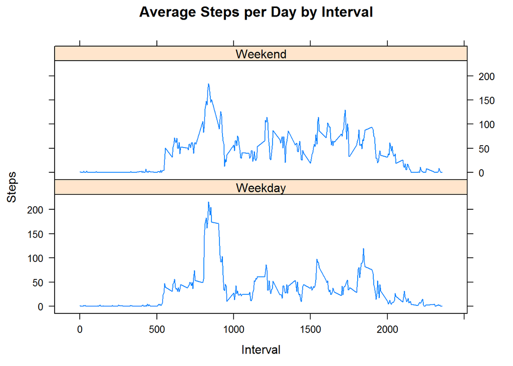

```r
#Define the name days (It's in spanish because I'm in Colombia)
weekdays <- c("lunes", "martes", "miercoles", "jueves","viernes")

activity_imputed$typeday=as.factor(ifelse(is.element(weekdays(as.Date(activity_imputed$date)),weekdays), "Weekday", "Weekend"))


steps_week_interval<- aggregate(steps~interval + typeday, activity_imputed, mean)

library(lattice)

xyplot(steps_week_interval$steps ~ steps_week_interval$interval|steps_week_interval$typeday, main="Average Steps per Day by Interval",xlab="Interval", ylab="Steps",layout=c(1,2), type="l")
```

```r
head(steps_week_interval$type)
```

```
## [1] Weekday Weekday Weekday Weekday Weekday Weekday
## Levels: Weekday Weekend
```